# Aside

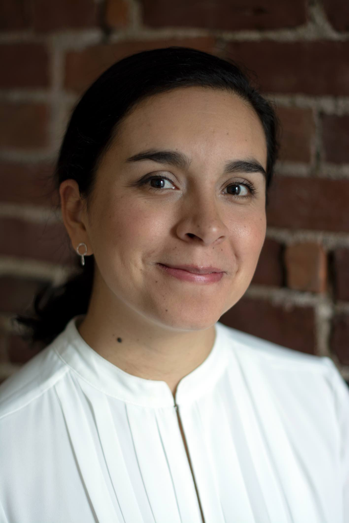

## Contact

- yinaquique@unm.edu
- [Website](https://yina-quique.github.io/)
- [Github](https://github.com/yina-quique)
- 0000-0001-9129-4742

## Key Interests

- Aphasia treatment outcomes
- Spanish speakers with aphasia
- Health services and outcomes research
- Technology for aphasia rehabilitation

## Disclaimer

[Download a PDF of this CV](https://github.com/yyinaa/website_YQ/raw/master/CV/cv.pdf)

Last updated on 2026-10-27.

# Main

## Yina Quique, PhD

I am a clinician-scientist committed to improving rehabilitation outcomes and healthcare services for stroke survivors with aphasia. I am especially interested in developing culturally-sensitive and language-specific interventions for Spanish speakers with aphasia.

## Education

### Postdoctoral Fellow

Northwestern University & Shirley Ryan AbilityLab, Chicago, IL

hideme

2021 — 2023

### Ph.D. Communication Science and Disorders

University of Pittsburgh, Pittsburgh, PA

hideme

2015 — 2020

- Dissertation: Get in Sync: Entrainment Mechanisms and Individual Characteristics Associated with Scripted-Sentence Learning in Aphasia

### M.S., Music Therapy

National University of Colombia, Bogota, Colombia

hideme

2010 — 2012

### B.A., Speech and Language Pathology

National University of Colombia, Bogota, Colombia

hideme

2002 — 2006

## Appointments & Positions

### Assistant Professor

Department of Speech and Hearing Sciences  
University of New Mexico (UNM),

hideme

2025 — Current

### Fogarty Global Health Fellow

HBNU Global Health Fellows Consortium  
Sponsored by the Fogarty International Center, National Institutes of Health (NIH)  
Mentors: Drs. Leora Cherney & Patricia Garcia, Colombia & Peru

hideme

2023 — 2024

### Postdoctoral Fellow, NIDILRR Advanced Rehabilitation Research Training (AART)

Center for Health Services & Outcomes Research  
Northwestern University  
Mentors: Drs. Leora Cherney, Allen Heinemann, Cindy Nowinski,

hideme

2021 — 2022

### Lab Manager and Graduate Research Assistant

Language Rehab and Cognition Lab  
University of Pittsburgh  
PI: William S. Evans,

hideme

2017 — 2020

### Graduate Student Researcher

Language and the Brain Lab  
University of Pittsburgh  
PI: Michael W. Dickey,

hideme

2015 — 2020

### Research Associate, WOC

Department of Speech Pathology and Audiology  
VA Pittsburgh Healthcare System,

hideme

2016 — 2017

## Grant Support

### NIDILRR Switzer Research Fellowship

Role: PI

hideme

2022

### NIDILRR Advanced Rehabilitation Research Training (AART)

Role: Postdoctoral Fellow

hideme

2021

### PhD Scholarship from the Council of Academic Programs in Communication Sciences and Disorders (CAPCSD)

Role: Predoctoral Fellow

hideme

2020

### New Century Scholars Doctoral Scholarship. American Speech-Language-Hearing Foundation

Role: Predoctoral Fellow

hideme

2019

### School of Health and Rehabilitation Sciences Doctoral Student Award

Role: Predoctoral Fellow

hideme

2019

### Tinker Summer Research Grant, Center for Latin American Studies, University of Pittsburgh

Role: Predoctoral Fellow

hideme

2017

### Fulbright Program Scholarship. US Department of State

Role: Predoctoral Fellow

hideme

2015 — 2019

## Publications

Mabin, J., Shrubsole, K., Copland, D., Pais, A., **Quique, Y.,** Brownsett, S., … Shiggins, C. (2026). Speech-language pathology interventions for multilingual people with aphasia across the International Classification of Functioning, Disability, and Health: a scoping review. Aphasiology, 1–32. https://doi.org/10.1080/02687038.2026.2753445

N/A

2026

Cherney, L., Diedrichs, V., Kinsey, L., & **Quique, Y.** Dose-Controlled Script Training for Aphasia: A Quasi-Randomized Pilot Clinical Trial Examining Treatment Frequency. American Journal of Speech-Language Pathology. 35(5), 2115–2137. doi.org/10.1044/2026_AJSLP-25-00603

N/A

2026

Riley, E., **Quique, Y.,** Haley, K., Jacks, A., & Richardson, J. (2026). Retrospective analysis of the relationship between post-stroke fatigue and aphasia severity. Archives of Physical Medicine and Rehabilitation. doi.org/10.1016/j.apmr.2026.07.002

N/A

2026

**Quique, Y.,** Pais, A., Isaksen, J., & Jagoe, C. (2026). Something old, something borrowed, something new: frameworks to guide cultural adaptations and their documentation in aphasia treatments. Aphasiology, 1–27. [doi:10.1080/02687038.2026.2627323](https://doi.org/10.1080/02687038.2026.2627323)

N/A

2026

**Quique, Y.,** Larkin, E., Heinemann, A., Cherney, L. (2026). Using Open-Source Software to Help Spanish Speakers With Aphasia Learn Everyday Sentences: A Single-Case Experimental Design. American Journal of Speech-Language Pathology, 35(1), 83-97. [doi:10.1044/2025_AJSLP-24-00550](https://pubs.asha.org/doi/10.1044/2025_AJSLP-24-00550)

N/A

2026

Martínez Ferreiro, S., **Quique, Y.,** Rodríguez, V., Méndez Orellana, C., (2026). Linguistic and cultural properties of the Spanish adaptation of the CAT (SP-CAT): pilot results from neurotypical subjects. Aphasiology, 40(2), 240-264. [doi:10.1080/02687038.2024.2319362](https://www.tandfonline.com/doi/full/10.1080/02687038.2024.2319362) **Shared first authorship**

N/A

2026

**Quique, Y.,** Pak-Hin Kong, A., Owusu Antwi, A., Jagoe, C. (2025). Language rights and publication practices in aphasia research: Lessons learned from developing aphasia assessments in multiple languages. Aphasiology. 1–18. [doi:10.1080/02687038.2025.2508444](https://www.tandfonline.com/doi/full/10.1080/02687038.2025.2508444)

N/A

2025

**Quique, Y.,** Martínez-Martínez, A., Almeida, G., Chávez, L., Aguilar, O. (2025). Examining aphasia rehabilitation in Colombia from the perspective of speech-language pathologists and neuropsychologists: a pilot study. Aphasiology. 1–28. [doi:10.1080/02687038.2025.2519332](https://www.tandfonline.com/doi/full/10.1080/02687038.2025.2519332#d1e227)

N/A

2025

Bennington, C., Isaksen, J., Shiggins, C., Beesley, E., Beesley, K., Simmons-Mackie, N., Worrall, L., **Quique, Y.,**… Wallace, S. (2025). International priorities for a unified aphasia awareness campaign: a nominal group technique study across five countries. Disability and Rehabilitation, 1–21. [doi:10.1080/09638288.2025.2510558](https://www.tandfonline.com/doi/full/10.1080/09638288.2025.2510558)

N/A

2025

Ginsberg-Jaeckle, M., Babbitt, E., **Quique, Y.,** Larkin, E., Escarcega, S., Cherney, L. (2025). Promoting collaboration between interpreters and speech-language pathologists: A pilot training to support interpreter agency during aphasia assessments. Translation and Interpreting Studies, 20(1), 78-104. [doi:10.1075/tis.23095.gin](https://benjamins.com/catalog/tis.23095.gin?srsltid=AfmBOoo7GXDwurce5LT0KX0olrqCJu_9yS-70ORd4cj0XB8WaFNVV3KQ)

N/A

2025

Hurtado, C., Rojas-Gualdrón, D. F…, **Quique, Y.,** & Koralnik, I. J. (2024). Neurologic manifestations of Long COVID in Colombia: a comparative analysis of post-hospitalization vs. non-hospitalized patients. Frontiers in Human Neuroscience, 18, 1450110. [doi:10.3389/fnhum.2024.1450110](https://pmc.ncbi.nlm.nih.gov/articles/PMC11347330/)

N/A

2024

**Quique, Y.,** Dickey, M., Dresang, H., (2024). Preliminary investigation of semantic memory assessments in Colombian adults with and without post-stroke aphasia. Neurology Perspectives, 4(1), 100139. [doi:10.1016/j.neurop.2023.100139](https://www.sciencedirect.com/science/article/pii/S2667049623001242)

N/A

2024

**Quique, Y.,** Gnanateja, GN., Dickey M., Evans W., Chandrasekaran B (2023). Examining cortical tracking of the speech envelope in post-stroke aphasia. Frontiers in Human Neuroscience. 17:1122480. [doi:10.3389/fnhum.2023.1122480](https://www.frontiersin.org/journals/human-neuroscience/articles/10.3389/fnhum.2023.1122480/full)

N/A

2023

**Quique, Y.,** Ashaie, S., Babbit, E., Hurwitz, R., Cherney, L., (2023). Fatigue influences social participation in aphasia: a cross-sectional and retrospective study using patient-reported measures. Archives of Physical Medicine and Rehabilitation, 104(8), 1282–1288. [doi:10.1016/j.apmr.2023.02.013](https://www.sciencedirect.com/science/article/pii/S000399932300148X?casa_token=IutxoiE_z0sAAAAA:9529Ks9IcKye3Sx0yeF4ZufXTuVnhyVMy03DmiP73yNd-S5k8yXFoNe7oRktkPjSrxUhPxuikw)

N/A

2023

Forero, L., Bernal, M., Aguilar, O., **Quique, Y.** (2023). Aphasia Treatments for Spanish Speakers With Aphasia: A Scoping Review. Revista de Investigación en Logopedia, 13(1), e81535. [doi:10.5209/rlog.81535](https://revistas.ucm.es/index.php/RLOG/article/view/81535) (available in Spanish)

N/A

2023

Cavanaugh, R., **Quique, Y.,** Swiderski, A., Kallhoff, L., Terhorst, L., Wambaugh, J., Hula, W., Evans, W. (2023). Reproducibility in small-N treatment research: a tutorial through the lens of aphasiology. Journal of Speech, Language, and Hearing Research. 6(66). 1908-1927. [doi:10.1044/2022_JSLHR-22-00333](https://pmc.ncbi.nlm.nih.gov/articles/PMC10465158/)

N/A

2023

**Quique, Y.,** Cavanaugh, R., Lescht, E., & Evans, W. S. (2022). Applying adaptive distributed practice to self-managed computer-based anomia treatment: A single-case experimental design. Journal of Communication Disorders. 99:106249. [doi:10.1016/j.jcomdis.2022.106249](https://www.sciencedirect.com/science/article/pii/S0021992422000685?via%3Dihub)

N/A

2022

Gnanateja, G. N., Devaraju, D. S., Heyne, M., **Quique, Y.,** Sitek, K., Tardif, M., … & Dial, H. R. (2022). On the role of neural oscillations across timescales in speech and music processing. Frontiers in Computational Neuroscience, 16, 872093. [doi:10.3389/fncom.2022.872093](https://pmc.ncbi.nlm.nih.gov/articles/PMC9260496/)

N/A

2022

Nguy, B., **Quique, Y.,** Cavanaugh, R., Evans, William S. (2022). Representation in aphasia research: an examination of US treatment studies published between 2009 and 2019. American Journal of Speech-Language Pathology. 31(3). 1424-1430. [doi:10.1044/2022_AJSLP-21-00269](https://pmc.ncbi.nlm.nih.gov/articles/PMC9567435/)

N/A

2022

Cavanaugh, R., **Quique, Y.,** Dickey, M.W., Hula, W.D., Boss, E., Evans, William S. (2022). Practice-related predictors of semantic feature verification treatment for aphasia. American Journal of Speech-Language Pathology, 31(5S), 2366–2377. [doi:10.1044/2021_AJSLP-21-00296](https://pubs.asha.org/doi/10.1044/2021_AJSLP-21-00296)

N/A

2022

**Quique, Y.,** Evans, W., Ortega-Llebaria, M., Zipse, L., M., & Dickey, M. (2022). Get in sync: Active Ingredients and Patient Profiles in Scripted-Sentence Learning in Spanish Speakers with Aphasia. Journal of Speech, Language, and Hearing Research. 65(4), 1478–1493. [doi:10.1044/2021_JSLHR-21-00060](https://pubs.asha.org/doi/10.1044/2021_JSLHR-21-00060)

N/A

2022

**Quique, Y**., Swiderski, A. M., Hula, W., & Dickey, M. (2021). Treatment of Underlying Forms: A Bayesian meta-analysis of the effects of treatment and person related variables on treatment response. Journal of Speech, Language, and Hearing Research. 64(11), 4308–4328. [doi:10.1044/2021_JSLHR-21-00131](https://pubs.asha.org/doi/10.1044/2021_JSLHR-21-00131) **Shared first authorship**

N/A

2021

Cavanaugh, R., Kravetz, C., Jarold, L., **Quique, Y.,** Turner, R., & Evans, W. S. (2021). Is There a Research-Practice Dosage Gap in Aphasia Rehabilitation? American Journal of Speech-Language Pathology, 30(5), 2115–2129. [doi:10.1044/2021_AJSLP-20-00257](https://pubs.asha.org/doi/10.1044/2021_AJSLP-20-00257)

N/A

2021

Evans, WS, Cavanaugh, R.B., **Quique, Y**, Boss, E, Starns, J.J., Hula, W.D. (2021). Playing with BEARS: Balancing Effort, Accuracy, and Response Speed in a Semantic Feature Verification Anomia Treatment Game. Journal of Speech, Language, and Hearing Research. Aug 9;64(8):3100-3126. [doi:10.1044/2021_JSLHR-20-00543](https://pubs.asha.org/doi/10.1044/2021_JSLHR-20-00543)

N/A

2021

Evans, WS, **Quique, Y**., (2021). Understanding speed-accuracy processing dynamics in aphasia using response time modeling. Seminars in Speech and Language. Jun;42(3):240-255. [doi:10.1055/s-0041-1727251](https://www.thieme-connect.com/products/ejournals/abstract/10.1055/s-0041-1727251)

N/A

2021

Evans, W. S., Hula, W.D., **Quique, Y.**, Starns, J.J. (2020). How much time do people with aphasia need to respond during picture naming? Estimating optimal response time cutoffs using a multinomial ex-gaussian approach. Journal of Speech, Language, and Hearing Research, 63(2), 599–614. [doi:10.1044/2019_JSLHR-19-00255](https://pubs.asha.org/doi/10.1044/2019_JSLHR-19-00255)

N/A

2020

**Quique, Y.** M., Evans, W. S., & Dickey, M. W., (2019). Acquisition and generalization responses in aphasia naming treatment: a meta-analysis of Semantic Feature Analysis outcomes. American Journal of Speech-Language Pathology, 28(1S), 230-246. [doi:10.1044/2018_AJSLP-17-0155](https://pubs.asha.org/doi/10.1044/2018_AJSLP-17-0155?url_ver=Z39.88-2003&rfr_id=ori:rid:crossref.org&rfr_dat=cr_pub%20%200pubmed)

N/A

2019

## Refereed Presentations

**Quique, Y.,** Muñoz, M., Centeno, J., Grasso, S. (2026). Challenges and resilience in aphasia research: perspectives from Hispanic/Latino researchers in the US. Pittsburgh, PA. Clinical Aphasiology Conference. Roundtable

N/A

2026

**Quique, Y.** (2025). Resources for the Treatment of Aphasia in Spanish-Speaking Individuals. Organización Puertorriqueña de Profesionales del Habla-Lenguaje y Audiología (OPPHLA) Conference (in Spanish). Puerto Rico: Invited Speaker.

N/A

2025

**Quique, Y.** (2025). Aphasia rehabilitation for Spanish speakers with aphasia: insights from the US, Peru, and Colombia. Clinical Aphasiology Conference. Albuquerque, NM. NIDCD Research Symposium in Clinical Aphasiology (RSCA): Invited Speaker

N/A

2025

**Quique, Y.,** Aguilar, O., Cherney, L. (2024). Cuidado usual, barreras y facilitadores de la rehabilitación de personas con afasia después de ACV en Colombia y Perú. XXVI Congreso Iberoamericano de Enfermedad Cerebro Vascular. 2024 Global Stroke Alliance. Bogota, Colombia. Poster.

N/A

2024

**Quique, Y.,** Aguilar, O., Cherney, L. (2024). Cuidado usual, barreras y facilitadores de la rehabilitación de personas con afasia en Colombia. IV Congreso de la Sociedad Colombiana de Neuropsicología. Barranquilla, Colombia. Oral presentation.

N/A

2024

Martínez-Ferreiro, S., **Quique, Y.,** Mendez-Orellana, C., (2023). From the CAT to the SP-CAT: The language battery. Abstract for poster presentation, 8th Nordic Aphasia Conference.

N/A

2023

**Quique, Y.** Diversidad en la investigación en la afasia. 2023 Observatorio Instituto Cervantes Symposium. Instituto Cervantes at Harvard University.

N/A

2023

Babbitt, E., **Quique, Y.,** Ginsberg-Jaeckle, M., Larkin, E., Escarcega, S., Cherney, L., (2022) Training Interpreters in Aphasia Assessments: A Pilot Study. Abstract for poster presentation, 51st annual Clinical Aphasiology Conference

N/A

2022

**Quique,Y.**, Cavanaugh, R.B., Starns, J.J., Boss, E., Hula, W.D., and Evans, W.S. (2020). Estimating the speed-accuracy tradeoff “Sweet Spot” in language performance for people with aphasia: replication and extension of a diffusion-model based approach. Abstract for poster presentation, 50th annual Clinical Aphasiology Conference

N/A

2021

Cavanaugh, R.B., **Quique, Y**., Boss, E, Hula, W.D., and Evans, W.S. (2020). Practicing with BEARS: Active Ingredients in Semantic Feature Analysis. Abstract for poster presentation, 51st annual Clinical Aphasiology Conference, Online

N/A

2021

Evans, W.S., Cavanaugh, R.B., **Quique, Y.**, Boss,E., Dickey, M.W., Doyle , P, Starns,J.J.,and Hula, W.D., (2021) BEARS-Balancing Effort, Accuracy, and Response Speed in semantic feature verification anomia treatment. Abstract for platform presentation, 50th annual Clinical Aphasiology Conference

N/A

2021

Cavanaugh, R.B., Kravetz, C., Jarold, L., **Quique, Y.**, Turner, R., Evans, W.S. Is there a research-practice dosage gap in aphasia rehabilitation? Abstract for poster presentation, Aphasia Access Leadership Summit, online.

N/A

2021

**Quique, Y.**, Evans, WS., Zipze, L., Dickey, MW., (2020) Get in sync: rhythm in speech entrainment as a mechanism for scripted-sentence learning in aphasia. Abstract for poster presentation, annual Academy of Aphasia.

N/A

2020

Evans, WS., **Quique, Y.**, Hula, WD., and Starns, J. (2019) How much time do PWA need for naming? Platform presentation, annual Clinical Aphasiology Conference. Whitefish, Montana.

N/A

2019

**Quique, Y.**, Dresang, H., Dickey, MW. (2018) Semantic memory for objects, actions & events in Colombian people with aphasia. Abstract for research symposium in Clinical Aphasiology selected poster presentation, annual Clinical Aphasiology Conference. Austin, Texas.

N/A

2018

**Quique, Y.**, Evans, WS and Dickey, MW. Acquisition & generalization responses in aphasia naming treatment: a meta-analysis of semantic feature analysis outcomes. (2017) Abstract for Research Symposium in Clinical Aphasiology selected poster presentation, annual Clinical Aphasiology Conference. Snowbird, Utah.

N/A

2017

**Quique, Y.** & Dickey, M. Syntactical processing of musical and linguistic information. (2017) Abstract for the Society for Music Perception and Cognition (SMPC) conference. San Diego, July 30-Aug 3, 2017.

N/A

2017

**Quique, Y.**, Dickey, MW. (2016). Acquisition & generalization responses in aphasia naming treatment: a meta-analysis of semantic feature analysis outcomes. Abstract for ASHA convention Technical Session. Philadelphia, Pennsylvania.

N/A

2016

## Teaching

Neurogenic Communication Disorders

hideme

2025, 2026

- SHS507: Neurogenic Communication Disorders. Number of credits: 4. Number of Students: 28-30. Level: Master of Speech-Language Pathology, UNM

Invited by the Temerty Faculty of Medicine, University of Toronto, Leadership Rehab Rounds. Webinar on May 15, 2024.

hideme

2024

- Guest speaker: Culturally-sensitive and adaptive interventions for aphasia

Invited by Universidad de los Andes. Nov 22, 2023. Auditorio Mario Laserna. Bogota, Colombia

hideme

2023

- Panelist: “Stroke and its consequences: realities and myths [ACV y sus secuelas: realidades y mitos]”

Introduction to aphasia. Invited by Dr. Natalia Santamaria Laorden. Ramapo College

hideme

2022

- Guest Lecture: So, what’s aphasia?

FOQUSAphasia. Invited by Dr. Brielle Stark

hideme

2022

- Guest Lecture: Let’s Talk about Spanish Speakers with Aphasia

Conversations about aphasia treatment (in Spanish). Invited by Universidad Nacional de Colombia

hideme

2021

Adult Neurogenic Disorders. University of Minnesota. Invited by Dr. Natalie Covington

hideme

2021

- Guest Lecture 1: Rhythm in aphasia interventions
- Guest Lecture 2: Case studies in adult neurological communication disorders

Achievement in Pedagogy Badge, University Center for Teaching and Learning - University of Pittsburgh

hideme

2019

College teaching. Online Education Center – Manuela Beltran University. Bogota, Colombia

hideme

2013

## Honors and Awards

Tavistock Trust for Aphasia Distinguished Scholar Award

hideme

2026

- https://aphasiatavistocktrust.org/distinguished-scholar/2026-recipients/

Advancing Academic-Research Careers (AARC) Award. ASHA

hideme

2026

Future Stroke Leader - World Stroke Organization (WSO)

hideme

2023

- https://www.world-stroke.org/world-stroke-future-leaders/community-members/yina-m-quique

Annual Sarah Baskin Research Manuscript Award. Category Postdoctoral Research Fellow. Shirley Ryan Ability Lab

hideme

2023

NIH-NIMHD Health Disparities Research Institute

hideme

2022

Pathways Program. ASHA

hideme

2021

NIH-NIDCD Fellowship: Research Symposium in Clinical Aphasiology

hideme

2020

National Institute on Deafness and Other Communication Disorders (NIDCD) sponsored. Academy of Aphasia Young Investigator Fellowship

hideme

2018

Summer School on Statistical Methods for Linguistics and Psychology

hideme

2018

Research Mentoring-Pair Travel Award for the ASHA convention

hideme

2018

NIH-NIDCD Fellowship: Research Symposium in Clinical Aphasiology

hideme

2018

NIH-NIDCD Fellowship: Research Symposium in Clinical Aphasiology

hideme

2017

Minority Student Leadership Program. ASHA Convention. Los Angeles, CA

hideme

2017

Academy of Neurologic Communication Disorders and Sciences (ANCDS) Student Fellow

hideme

2016

National University of Colombia Graduate Fellowship (2 years full tuition)

hideme

2013

## Certification, Licensure, Memberships, and Service

Member, American Congress of Rehabilitation Medicine (ACRM)

hideme

2021 — Current

Member, Collaboration of Aphasia Trialists (CATs). Societal Impact and Reintegration Research Group. Global Engagement Group

hideme

2018 — Current

Member, Center for Latin American Studies (CLAS).

hideme

2015 — Current

Member, National Association of Medical Spanish (NAMS).

hideme

2020 — 2025

Member, Society for Music Perception and Cognition (SMPC).

hideme

2016 — 2018